# 506Assignment5

Author

Jiaqi Sun

Github repository: [Github](https://github.com/AlanGalaxy/506A5)

## Problem 1

Load the package and data.

```r
library(ggplot2)
library(tidyverse)
nnmaps <- read.csv("D:/Code/R/506A5/chicago-nmmaps.csv")
nnmaps$date <- as.Date(nnmaps$date)
# plot(nnmaps$o3 ~ nnmaps$date)
summary(nnmaps)
```

```
     city                date                 temp          o3
 Length:1461        Min.   :1997-01-01   Min.   :-3   Min.   : 0.08584
 Class :character   1st Qu.:1998-01-01   1st Qu.:36   1st Qu.:10.92419
 Mode  :character   Median :1999-01-01   Median :52   Median :18.65149
                    Mean   :1999-01-01   Mean   :51   Mean   :19.23597
                    3rd Qu.:2000-01-01   3rd Qu.:67   3rd Qu.:26.20476
                    Max.   :2000-12-31   Max.   :90   Max.   :54.68764

    dewpoint           pm10             season               yday
 Min.   :-10.38   Min.   :  0.2033   Length:1461        Min.   :  1.0
 1st Qu.: 28.10   1st Qu.: 18.3844   Class :character   1st Qu.: 92.0
 Median : 41.20   Median : 28.8499   Mode  :character   Median :183.0
 Mean   : 41.36   Mean   : 32.0928                      Mean   :183.1
 3rd Qu.: 56.25   3rd Qu.: 41.0738                      3rd Qu.:274.0
 Max.   : 77.10   Max.   :125.3844                      Max.   :366.0
                  NA's   :17
    month           month_numeric         year
 Length:1461        Min.   : 1.000   Min.   :1997
 Class :character   1st Qu.: 4.000   1st Qu.:1998
 Mode  :character   Median : 7.000   Median :1999
                    Mean   : 6.523   Mean   :1999
                    3rd Qu.:10.000   3rd Qu.:2000
                    Max.   :12.000   Max.   :2000
```

(a)

Calculate the average temperature in Celsius. Use `ggplot` to plot the data.

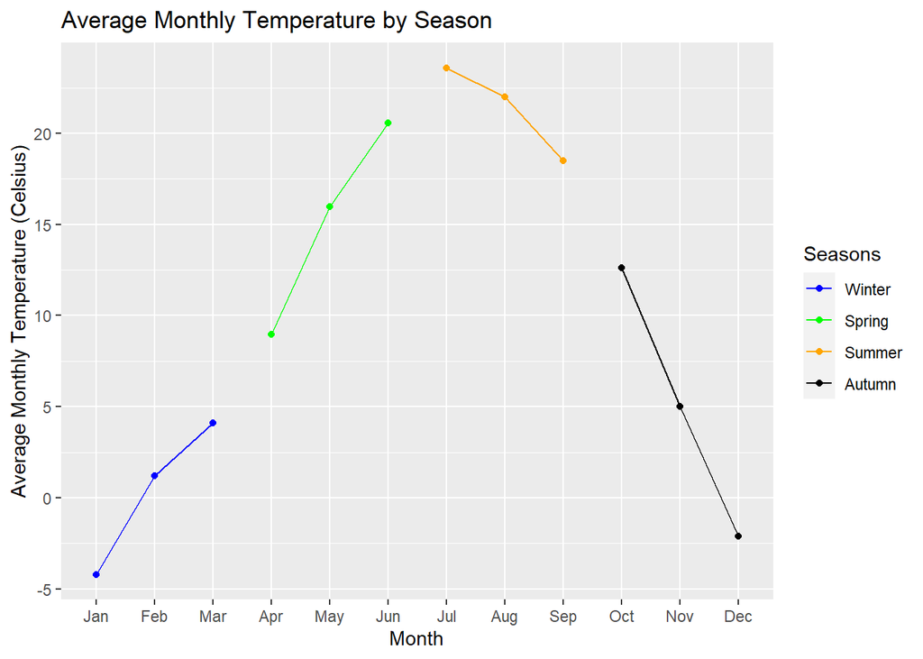

```r
month_mean <- nnmaps %>%
  group_by(month, season) %>%
  # get the average temp
  summarise(mean_temp = mean(temp)) %>%
  # change to celsius
  mutate(mean_temp = (mean_temp - 32) / 1.8) %>%
  ungroup()
ggplot(data = month_mean,
       mapping = aes(x = month, y = mean_temp,color = season, group = season)) +
  # plot the points and lines
  geom_point() +
  geom_line() +
  # set the legend and order
  scale_color_manual(name = "Seasons", values = c("Winter" = "blue",
                                                  "Spring" = "green",
                                                  "Summer" = "orange",
                                                  "Autumn" = "black"),
                     limits = c("Winter", "Spring", "Summer", "Autumn")) +
  # set the x-axis
  scale_x_discrete(limits = c("Jan", "Feb", "Mar", "Apr", "May", "Jun", "Jul",
                            "Aug", "Sep", "Oct", "Nov", "Dec")) +
  # set the labels
  labs(x = "Month", y = "Average Monthly Temperature (Celsius)", color = "Season",
       title = "Average Monthly Temperature by Season")
```

(b)

Calculate the data and pivot into long data. Use `ggplot` to plot the data.

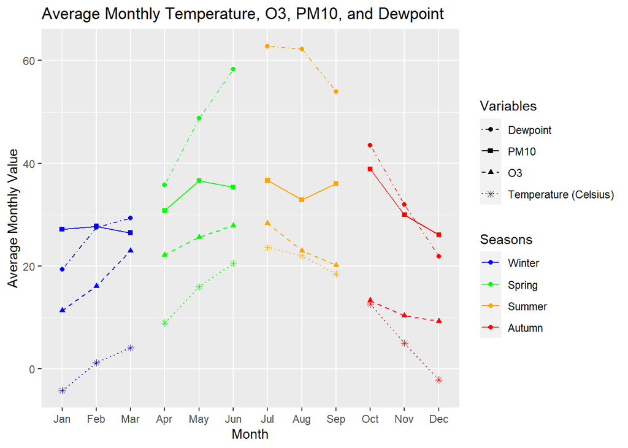

```r
library(tidyr)

month_mean2 <- nnmaps %>%
  group_by(month, season) %>%
  # calculate the average data
  summarise(mean_temp = mean(temp),
            mean_o3 = mean(o3),
            mean_pm10 = mean(pm10, na.rm = TRUE),
            mean_dewpoint = mean(dewpoint)) %>%
  # change to celsius
  mutate(mean_temp = (mean_temp - 32) / 1.8) %>%
  ungroup()%>%
  # pivot the data to be longer
  pivot_longer(cols = starts_with("mean_"), names_to = "variable",
               values_to = "value")
ggplot(month_mean2, aes(x = month, y = value, color = season, group = interaction(season, variable), linetype = variable, shape = variable)) +
  geom_point() +
  geom_line() +
  # set the legend and seasons' color
  scale_color_manual(name = "Seasons", values = c("Winter" = "blue",
                                                  "Spring" = "green",
                                                  "Summer" = "orange",
                                                  "Autumn" = "red"),
                     limits = c("Winter", "Spring",
                                "Summer", "Autumn")) +
  # set the legend and point type
  scale_shape_manual(name = "Variables", values = c("mean_temp" = 8,
                                                    "mean_o3" = 17,
                                                    "mean_pm10" = 15,
                                                    "mean_dewpoint" = 19),
                     labels = c("mean_temp" = "Temperature (Celsius)",
                                "mean_o3" = "O3",
                                "mean_pm10" = "PM10",
                                "mean_dewpoint" = "Dewpoint"),
                     limits = c("mean_dewpoint", "mean_pm10",
                                "mean_o3", "mean_temp")) +
  # set the legend and line type
  scale_linetype_manual(name = "Variables", values = c("mean_temp" = "dotted",
                                                       "mean_o3" = "dashed",
                                                       "mean_pm10" = "solid",
                                                       "mean_dewpoint" = "dotdash"),
                        labels = c("mean_temp" = "Temperature (Celsius)",
                                   "mean_o3" = "O3",
                                   "mean_pm10" = "PM10",
                                   "mean_dewpoint" = "Dewpoint"),
                        limits = c("mean_dewpoint", "mean_pm10",
                                   "mean_o3", "mean_temp")) +
  # set the x-axis
  scale_x_discrete(limits = c("Jan", "Feb", "Mar", "Apr", "May", "Jun", "Jul",
                            "Aug", "Sep", "Oct", "Nov", "Dec")) +
  # set the labels
  labs(x = "Month", y = "Average Monthly Value", color = "Variable",
       title = "Average Monthly Temperature, O3, PM10, and Dewpoint")
```

The data in different seasons are in different colors, and different variables are in different point-type and line-type.

From the picture, “PM10” is the variable has the least seasonal trend.

## Problem 2

(a)

Set the class “poly”.

```r
setClass("poly",
         slots = c(coef = "numeric",
                   degree = "numeric"))
```

Define the constructor. The first vector represents the coefficients, the second represents the degree.

```r
makePoly <- function(x, y) {
  # first use the validator defined below to check if the two vector make sense
  new("poly", coef = x, degree = y)
  # order the two vector by the degree of x
  index <- order(y, decreasing = TRUE)
  x <- x[index]
  y <- y[index]
  # return the ordered poly
  return(new("poly", coef = x, degree = y))
}
```

Define the validator to check whether the two vectors have the same length.

```r
setValidity("poly", function(object) {
  # check the same length
  if (length(object@coef) != length(object@degree)) {
    stop("The coefficients and degrees do not have the same length!\n")
  }
  return(TRUE)
})
```

```
Class "poly" [in ".GlobalEnv"]

Slots:

Name:     coef  degree
Class: numeric numeric
```

Define the `show` method.

```r
setMethod("show", "poly", function(object) {
  coef <- object@coef
  degree <- object@degree
  equation <- ""

  # Print the first term
  # In order to make sure the equation is well presented, this can be separated into
  # different cases.
  if (degree[1] == 0) {
    if (coef[1] > 0) {
      equation <- as.character(coef[1])
    } else {
      equation <- paste("- ", abs(coef[1]), sep = "")
    }
  } else if (degree[1] == 1) {
    if (coef[1] == 1) {
      equation <- "x"
    } else if (coef[1] > 0) {
      equation <- paste(coef[1], "x", sep = "")
    } else if (coef[1] == -1) {
      equation <- "- x"
    } else {
      equation <- paste("- ", abs(coef[1]), sep = "")
    }
  } else {
    if (coef[1] == 1) {
      equation <- paste("x^", degree[1], sep = "")
    } else if (coef[1] > 0) {
      equation <- paste(coef[1], "x^", degree[1], sep = "")
    } else if (coef[1] == -1) {
      equation <- paste("- ", "x^", degree[1], sep = "")
    } else {
      equation <- paste("- ", abs(coef[1]), "x^", degree[1], sep = "")
    }
  }

  # Print the rest terms
  if (length(coef) > 1) {
    for (i in 2:length(coef)) {
      if (degree[i] == 0) {
        if (coef[i] > 0) {
          equation <- paste(equation, " + ", coef[i], sep = "")
        } else {
          equation <- paste(equation, " - ", abs(coef[i]), sep = "")
        }
      } else if (degree[i] == 1) {
        if (coef[i] == 1) {
          equation <- paste(equation, " + x", sep = "")
        } else if (coef[i] > 0) {
          equation <- paste(equation, " + ", coef[i], "x", sep = "")
        } else if (coef[i] == -1) {
          equation <- paste(equation, " - x", sep = "")
        } else {
          equation <- paste(equation, " - ", abs(coef[i]), "x", sep = "")
        }
      } else {
        if (coef[i] == 1) {
          equation <- paste(equation, " + x^", degree[i], sep = "")
        } else if (coef[i] > 0) {
          equation <- paste(equation, " + ", coef[i], "x^", degree[i], sep = "")
        } else if (coef[i] == -1){
          equation <- paste(equation, " - x^", degree[i], sep = "")
        } else {
          equation <- paste(equation, " - ", abs(coef[i]), "x^", degree[i], sep = "")
        }
      }
    }
  }
  cat(equation, "\n")
  return(invisible(object))
})
```

Define the addition & subtraction.

```r
setMethod("+", signature("poly", "poly"),
          function(e1, e2) {
            # get all the degrees in two poly
            all_degrees <- unique(c(e1@degree, e2@degree))
            # add the corresponding coefficients
            result_coefficients <- sapply(all_degrees, function(power) {
              sum(e1@coef[e1@degree == power], na.rm = TRUE) +
                sum(e2@coef[e2@degree == power], na.rm = TRUE)
            })
            # return the new poly
            makePoly(result_coefficients, all_degrees)
          })

setMethod("-", signature("poly",
                         "poly"),
          function(e1, e2) {
            all_degrees <- unique(c(e1@degree, e2@degree))
            result_coefficients <- sapply(all_degrees, function(power) {
              sum(e1@coef[e1@degree == power], na.rm = TRUE) -
                sum(e2@coef[e2@degree == power], na.rm = TRUE)
            })

            makePoly(result_coefficients, all_degrees)
          })
```

(b)

```r
p1 <- makePoly(c(3,2), c(2,0))
p2 <- makePoly(c(7,-2,-1,17), c(3,2,1,0))

p1
```

```
3x^2 + 2
```

```r
p2
```

```
7x^3 - 2x^2 - x + 17
```

```r
p1 + p2
```

```
7x^3 + x^2 - x + 19
```

```r
p1 - p2
```

```
- 7x^3 + 5x^2 + x - 15
```

As demonstrated above, $x^1$ and $x^0$ are well handled.

Additional examples:

$\pm1$ in coefficient is well handled.

```r
makePoly(c(1,-1), c(2,1))
```

```
x^2 - x
```

Negative degree is well handled.

```r
makePoly(c(-1,2,3), c(0,-1,-2))
```

```
- 1 + 2x^-1 + 3x^-2
```

Non-integer is well handled.

```r
makePoly(c(-1,2,3), c(1.5, 0.5,-0.5))
```

```
- x^1.5 + 2x^0.5 + 3x^-0.5
```

Unordered input in degree is well handled.

```r
makePoly(c(1,2,3), c(1,0,2))
```

```
3x^2 + x + 2
```

## Problem 3

Load the package and data.

```r
library(data.table)
library(nycflights13)

data(flights)
data(airports)

flights <- as.data.table(flights)
airports <- as.data.table(airports)
```

(a)

Generate the full `data.table` for departure delay.

```r
departure_delay <- flights |>
  # calcualte the mean and median statistics
  _[, .(mean_dep_delay = mean(dep_delay, na.rm = TRUE),
        median_dep_delay = median(dep_delay, na.rm = TRUE)),
    by = .(origin)] |>
  # merge two data.table
  merge(x = _, airports, by.x = "origin", by.y = "faa", all.x = TRUE) |>
  # select the final table
  _[, .(airport_name = name, mean_dep_delay, median_dep_delay)] |>
  # make it in right order
  _[order(-mean_dep_delay)]

print(departure_delay, n = nrow(departure_delay))
```

```
          airport_name mean_dep_delay median_dep_delay
1: Newark Liberty Intl       15.10795               -1
2: John F Kennedy Intl       12.11216               -1
3:          La Guardia       10.34688               -3
```

Generate the full `data.table` for arrival delay.

```r
arrival_delay <- flights |>
  # calcualte the mean and median statistics
  _[, .(mean_arr_delay = mean(arr_delay, na.rm = TRUE),
        median_arr_delay = median(arr_delay, na.rm = TRUE),
        count = .N),
    by = .(dest)] |>
  # merge two data.table
  merge(x = _, airports, by.x = "dest", by.y = "faa", all.x = TRUE) |>
  # select the final table
  _[count >= 10, .(airport_name = name, mean_arr_delay, median_arr_delay)] |>
  # make it in right order
  _[order(-mean_arr_delay)]

print(arrival_delay, n = nrow(arrival_delay))
```

```
                             airport_name mean_arr_delay median_arr_delay
  1:                Columbia Metropolitan    41.76415094             28.0
  2:                           Tulsa Intl    33.65986395             14.0
  3:                    Will Rogers World    30.61904762             16.0
  4:                 Jackson Hole Airport    28.09523810             15.0
  5:                        Mc Ghee Tyson    24.06920415              2.0
  6:               Dane Co Rgnl Truax Fld    20.19604317              1.0
  7:                        Richmond Intl    20.11125320              1.0
  8:        Akron Canton Regional Airport    19.69833729              3.0
  9:                      Des Moines Intl    19.00573614              0.0
 10:                   Gerald R Ford Intl    18.18956044              1.0
 11:                      Birmingham Intl    16.87732342             -2.0
 12:         Theodore Francis Green State    16.23463687              1.0
 13: Greenville-Spartanburg International    15.93544304             -0.5
 14:    Cincinnati Northern Kentucky Intl    15.36456376             -3.0
```

[output cut: 89 more lines]

(b)

Generate the full `data.table`.

```r
data(planes)
planes <- as.data.table(planes)

fast_model_num <- flights |>
  # merge two data.table
  merge(x = _, planes, by = "tailnum", all.x = TRUE) |>
  # calculate the average speed in MPH for each model
  _[, .(average_speed = mean(distance / air_time, na.rm = TRUE) * 60,
        num_flight = .N), by = model] |>
  # make it in right order
  _[order(-average_speed)] |>
  # select the first row
  _[1, .(model, average_speed, num_flight)]

print(fast_model_num, n = nrow(fast_model_num))
```

```
     model average_speed num_flight
1: 777-222      482.6254          4
```